# Biostat 203B Homework 3

Due Feb 23 @ 11:59PM

Author

Yang An and UID:106332601

Load necessary libraries (you can add more as needed).

```r
library(arrow)
library(memuse)
library(pryr)
library(R.utils)
library(tidyverse)
```

Display your machine memory.

```r
memuse::Sys.meminfo()
```

In this exercise, we use tidyverse (ggplot2, dplyr, etc) to explore the [MIMIC-IV](https://mimic.mit.edu/docs/iv/) data introduced in [homework 1](https://ucla-biostat-203b.github.io/2024winter/hw/hw1/hw1.html) and to build a cohort of ICU stays.

## Q1. Visualizing patient trajectory

Visualizing a patient’s encounters in a health care system is a common task in clinical data analysis. In this question, we will visualize a patient’s ADT (admission-discharge-transfer) history and ICU vitals in the MIMIC-IV data.

### Q1.1 ADT history

A patient’s ADT history records the time of admission, discharge, and transfer in the hospital. This figure shows the ADT history of the patient with `subject_id` 10001217 in the MIMIC-IV data. The x-axis is the calendar time, and the y-axis is the type of event (ADT, lab, procedure). The color of the line segment represents the care unit. The size of the line segment represents whether the care unit is an ICU/CCU. The crosses represent lab events, and the shape of the dots represents the type of procedure. The title of the figure shows the patient’s demographic information and the subtitle shows top 3 diagnoses.

[figure not shown]

Do a similar visualization for the patient with `subject_id` 10013310 using ggplot.

Hint: We need to pull information from data files `patients.csv.gz`, `admissions.csv.gz`, `transfers.csv.gz`, `labevents.csv.gz`, `procedures_icd.csv.gz`, `diagnoses_icd.csv.gz`, `d_icd_procedures.csv.gz`, and `d_icd_diagnoses.csv.gz`. For the big file `labevents.csv.gz`, use the Parquet format you generated in Homework 2. For reproducibility, make the Parquet folder `labevents_pq` available at the current working directory `hw3`, for example, by a symbolic link. Make your code reproducible.

```r
sid <- 10013310
```

Patients info:

```r
sid_info <- read_csv("~/mimic/hosp/patients.csv.gz") |>
  filter(subject_id == sid) |>
  print(width = Inf)
```

ADT information:

```r
sid_adt <- read_csv("~/mimic/hosp/transfers.csv.gz") |>
  filter(subject_id == sid) |>
  print(width = Inf)
```

Admissions:

```r
sid_adm <- read_csv("~/mimic/hosp/admissions.csv.gz") |>
  filter(subject_id == sid) |>
  print(width = Inf)
```

Lab event:

```r
sid_lab <- open_dataset("labevents_pq") |>
  filter(subject_id == sid) |>
  collect() |>
  print(width = Inf)
```

Procedure:

```r
sid_proc <- read_csv("~/mimic/hosp/procedures_icd.csv.gz",
  show_col_types = FALSE
 ) |>
  filter(subject_id == sid) |>
  left_join(read_csv("~/mimic/hosp/d_icd_procedures.csv.gz",
                     show_col_types = FALSE), by = c("icd_code", "icd_version")
  ) |>
  print(width = Inf)
```

Diagnosis:

```r
sid_diag <- read_csv("~/mimic/hosp/diagnoses_icd.csv.gz",
  show_col_types = FALSE
 ) |>
  filter(subject_id == sid) |>
  left_join(read_csv("~/mimic/hosp/d_icd_diagnoses.csv.gz",
                     show_col_types = FALSE), by = c("icd_code", "icd_version")
  ) |>
  print(width = Inf)
```

Visualize:

```r
ggplot() +
  geom_segment(
    data = sid_adt |> filter(eventtype != "discharge"),
    mapping = aes(
      x = intime,
      xend = outtime,
      y = "ADT",
      yend = "ADT",
      color = careunit,
      linewidth = str_detect(careunit, "(ICU|CCU)")
      ),
  ) +
  geom_point(data = sid_lab |> distinct(charttime, .keep_all = TRUE),
             mapping = aes(x = charttime, y = "Lab"),
             shape = '+',
             size = 5
             ) +
  geom_jitter(
    data = sid_proc,
    mapping = aes(x = chartdate + hours(12),
                  y = "Procedure",
                  shape = str_sub(long_title, 1, 25)
                  ),
    size = 3,
    height = 0
  ) +
  labs(
    title = str_c(
      "Patient ", sid, ", ",
      sid_info$gender, ", ",
      sid_info$anchor_age + year(sid_adm$admittime[1]) - sid_info$anchor_year,
      "years old, ",
      str_to_lower(sid_adm$race[1])
    ),
    subtitle = str_c(str_to_lower(sid_diag$long_title[1:3]), collapse = "\n"),
    x = "Calendar Time",
    y = "",
    color = "Care Unit",
    shape = "Procedure"
  ) +
  guides(linewidth = "none") +
  scale_y_discrete(limits = rev) +
  theme_light() +
  theme(legend.position = "bottom", legend.box = "vertical")
```

```r
# save the plot
ggsave("10013310_adt.png")
```

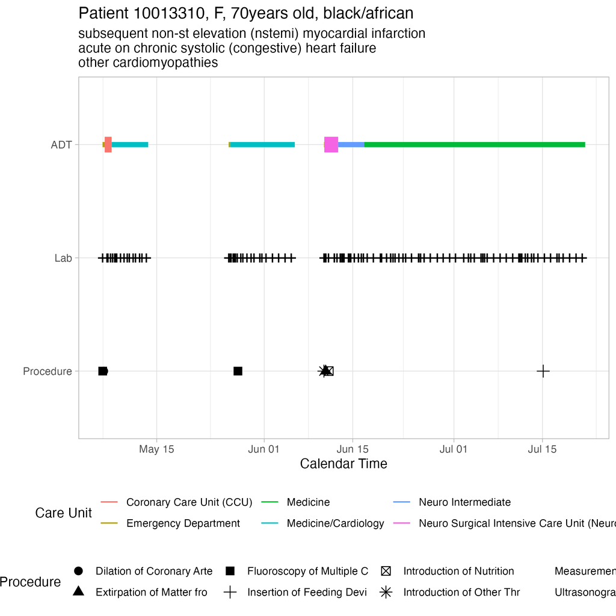

### Q1.2 ICU stays

ICU stays are a subset of ADT history. This figure shows the vitals of the patient `10001217` during ICU stays. The x-axis is the calendar time, and the y-axis is the value of the vital. The color of the line represents the type of vital. The facet grid shows the abbreviation of the vital and the stay ID.

[figure not shown]

Do a similar visualization for the patient `10013310`.

```r
sid <- 10013310
```

```r
sid_icu <- read_csv("~/mimic/icu/icustays.csv.gz",
                    show_col_types = FALSE) |>
  filter(subject_id == sid)
```

```r
sid_chart <- arrow::open_dataset("chartevents_pq",
                                 format = "parquet") |>
  dplyr::filter(subject_id == sid) |>
  dplyr::filter(itemid %in% c(220045,
                              220180,
                              220179,
                              223761,
                              220210)) |>
  collect()
```

```r
merged_data <- sid_icu |>
  left_join(sid_chart, by = "stay_id")

merged_data$item_label <-
  factor(merged_data$itemid,
         levels = c('220045',
                    '220180',
                    '220179',
                    '220210',
                    '223761'),
         labels = c('HR',
                    'NBPd',
                    'NBPs',
                    'RR',
                    'Temperature Fahrenheit'))
```

```r
sid_icu |>
  ggplot() +

  geom_line(data = merged_data, aes(x = charttime,
                                    y = valuenum,
                                    color = factor(itemid))) +

  geom_point(data = merged_data, aes(x = charttime,
                                     y = valuenum,
                                     color = factor(itemid))) +

  facet_grid(vars(item_label), vars(stay_id), scales = "free") +

  theme_minimal() +
  theme( strip.placement = "outside",
         legend.position = "none",
         strip.background = element_rect(fill = "grey",
                                         color = "white"),
         strip.text.x = element_text(color = "white"),
         strip.text.y = element_text(color = "white")) +

  labs(
    x = "",
    y = "",
    title = str_c("Patient ",sid, " ICU stays - Vitals"))+
  scale_x_datetime(date_labels = "%b %d %H:%M",
                   guide = guide_axis(n.dodge = 2))
```

```r
# save the plot
ggsave("10013310_icu.png")
```

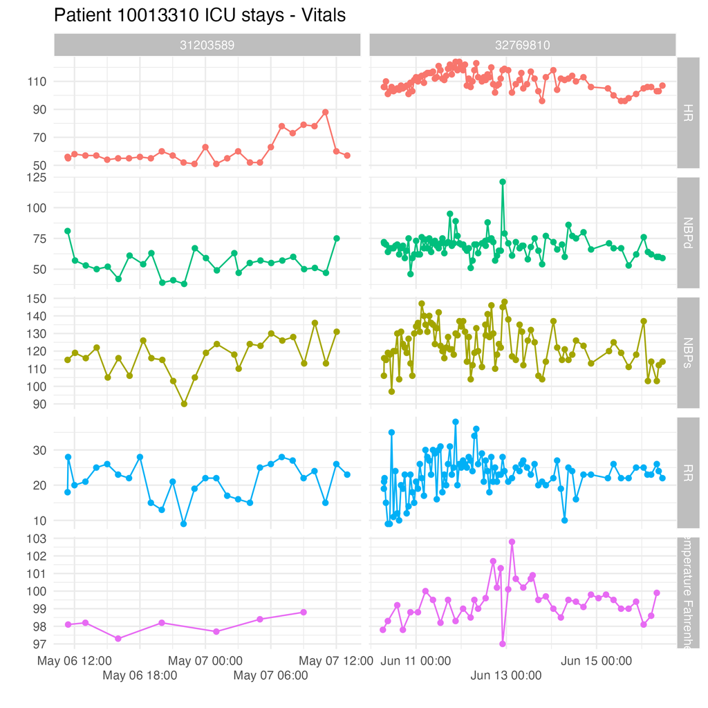

## Q2. ICU stays

`icustays.csv.gz` (https://mimic.mit.edu/docs/iv/modules/icu/icustays/) contains data about Intensive Care Units (ICU) stays. The first 10 lines are

```bash
zcat < ~/mimic/icu/icustays.csv.gz | head
```

### Q2.1 Ingestion

Import `icustays.csv.gz` as a tibble `icustays_tble`.

```r
icustays_tble <- read_csv("~/mimic/icu/icustays.csv.gz") |>
  print(width = Inf)
```

### Q2.2 Summary and visualization

How many unique `subject_id`?

```r
icustays_tble %>%
  distinct(subject_id) %>%
  count()
```

Can a `subject_id` have multiple ICU stays? Summarize the number of ICU stays per `subject_id` by graphs.

```r
icustays_tble %>%
  count(subject_id) %>%
  ggplot(aes(x = n)) +
  geom_bar() +
  labs(title = "Number of ICU stays per patient",
       x = "Number of ICU stays",
       y = "Number of patients") +
  theme_minimal()
```

## Q3. `admissions` data

Information of the patients admitted into hospital is available in `admissions.csv.gz`. See https://mimic.mit.edu/docs/iv/modules/hosp/admissions/ for details of each field in this file. The first 10 lines are

```bash
zcat < ~/mimic/hosp/admissions.csv.gz | head
```

### Q3.1 Ingestion

Import `admissions.csv.gz` as a tibble `admissions_tble`.

```r
admissions_tble <- read_csv("~/mimic/hosp/admissions.csv.gz") |>
  print(width = Inf)
```

### Q3.2 Summary and visualization

Summarize the following information by graphics and explain any patterns you see.

- number of admissions per patient
- admission hour (anything unusual?)
- admission minute (anything unusual?)
- length of hospital stay (from admission to discharge) (anything unusual?)
- age at admission (anything unusual?)

```r
admissions_tble %>%
  count(subject_id) %>%
  ggplot(aes(x = n)) +
  geom_bar() +
  labs(title = "Number of admissions per patient",
       x = "Number of admissions",
       y = "Number of patients") +
  theme_minimal()
```

```r
admissions_tble %>%
  ggplot(aes(x = hour(admittime))) +
  geom_bar() +
  labs(title = "Admission hour",
       x = "Hour",
       y = "Count") +
  theme_minimal()
```

```r
admissions_tble %>%
  ggplot(aes(x = minute(admittime))) +
  geom_bar() +
  labs(title = "Admission minute",
       x = "Minute",
       y = "Count") +
  theme_minimal()
```

```r
admissions_tble %>%
  mutate(dischtime = as.POSIXct(dischtime),
         admittime = as.POSIXct(admittime)) %>%
  mutate(length_of_stay = dischtime - admittime) %>%
  ggplot(aes(x = length_of_stay)) +
  geom_histogram() +
  labs(title = "Length of hospital stay",
       x = "Length of stay",
       y = "Count") +
  theme_minimal()
```

```r
patients_tble <- read_csv("~/mimic/hosp/patients.csv.gz") |>
  print(width = Inf)
```

```r
patients_tble %>%
  ggplot(aes(x = anchor_age)) +
  geom_histogram() +
  labs(title = "Age distribution of patients",
       x = "Age",
       y = "Count") +
  theme_minimal()
```

According to the [MIMIC-IV documentation](https://mimic.mit.edu/docs/iv/about/concepts/#date-shifting),

> All dates in the database have been shifted to protect patient confidentiality. Dates will be internally consistent for the same patient, but randomly distributed in the future. Dates of birth which occur in the present time are not true dates of birth. Furthermore, dates of birth which occur before the year 1900 occur if the patient is older than 89. In these cases, the patient’s age at their first admission has been fixed to 300.

## Q4. `patients` data

Patient information is available in `patients.csv.gz`. See https://mimic.mit.edu/docs/iv/modules/hosp/patients/ for details of each field in this file. The first 10 lines are

```bash
zcat < ~/mimic/hosp/patients.csv.gz | head
```

### Q4.1 Ingestion

Import `patients.csv.gz` (https://mimic.mit.edu/docs/iv/modules/hosp/patients/) as a tibble `patients_tble`.

```r
patients_tble <- read_csv("~/mimic/hosp/patients.csv.gz") |>
  print(width = Inf)
```

### Q4.2 Summary and visualization

Summarize variables `gender` and `anchor_age` by graphics, and explain any patterns you see.

```r
patients_tble %>%
  ggplot(aes(x = gender)) +
  geom_bar() +
  labs(title = "Number of patients class by gender",
       x = "gender",
       y = "Number of patients") +
  theme_minimal()
```

```r
patients_tble %>%
  ggplot(aes(x = anchor_age)) +
  geom_histogram() +
  labs(title = "Age distribution of patients",
       x = "Age",
       y = "Count") +
  theme_minimal()
```

```r
library(tidyverse)
library(gridExtra)
p1 <- ggplot(data = patients_tble) +
  geom_bar(mapping = aes(x = anchor_age, fill = gender)) +
  labs(title = "") +
  labs(x = "Anchor age (years)", fill = "Gender")
max(patients_tble$anchor_age)
grid.arrange(p1, ncol = 2)
```

## Q5. Lab results

`labevents.csv.gz` (https://mimic.mit.edu/docs/iv/modules/hosp/labevents/) contains all laboratory measurements for patients. The first 10 lines are

```bash
zcat < ~/mimic/hosp/labevents.csv.gz | head
```

`d_labitems.csv.gz` (https://mimic.mit.edu/docs/iv/modules/hosp/d_labitems/) is the dictionary of lab measurements.

```bash
zcat < ~/mimic/hosp/d_labitems.csv.gz | head
```

We are interested in the lab measurements of creatinine (50912), potassium (50971), sodium (50983), chloride (50902), bicarbonate (50882), hematocrit (51221), white blood cell count (51301), and glucose (50931). Retrieve a subset of `labevents.csv.gz` that only containing these items for the patients in `icustays_tble`. Further restrict to the last available measurement (by `storetime`) before the ICU stay. The final `labevents_tble` should have one row per ICU stay and columns for each lab measurement.

Hint: Use the Parquet format you generated in Homework 2. For reproducibility, make `labevents_pq` folder available at the current working directory `hw3`, for example, by a symbolic link.（write in ternimal)

```r
dlabitems_tble <-
  read_csv("~/mimic/hosp/d_labitems.csv.gz", show_col_types = FALSE) |>
  filter(itemid %in% c(
    50912,
    50971,
    50983,
    50902,
    50882,
    51221,
    51301,
    50931
    )) |>
  mutate(itemid = as.integer(itemid)) |>
  print(width = Inf)
```

```r
icustays_tble <- read.csv("~/mimic/icu/icustays.csv.gz") |>
  print(width = Inf)
```

```r
(labevents_tble_orig <- open_dataset("labevents_pq") |>
  select(subject_id, itemid, storetime, valuenum) |>
  filter(
    itemid %in% pull(dlabitems_tble, itemid),
    subject_id %in% pull(icustays_tble, subject_id)
    ) |>
  collect() |>
  print(width = Inf)) |>
  system.time()
```

```r
(labevents_tble <- labevents_tble_orig |>
  # pull in the intime of ICU stays
  left_join(
    select(icustays_tble, subject_id, stay_id, intime),
    by = c("subject_id")
    ) |>
  # only keep lab items available to provider before this ICU stay
  filter(storetime < intime) |>
  # group by itemid
  group_by(subject_id, stay_id, itemid) |>
  # only keep the last storetime for each item before intime
  # slice_max(storetime, n = 1) |> # this function takes longer
  arrange(storetime, .by_group = TRUE) |>
  slice_tail(n = 1) |>
  # do not need charttime, storetime, and intime anymore
  select(-storetime, -intime) |>
  ungroup() |>
  pivot_wider(names_from = itemid, values_from = valuenum) |>
  # more informative column names
  rename_at(
    vars(as.character(dlabitems_tble$itemid)),
    ~str_to_lower(dlabitems_tble$label)
    ) %>%
  rename(wbc = `white blood cells`) |> #, calcium = `calcium, total`
  arrange(subject_id, stay_id) |>
  print(width = Inf)) |>
  system.time()
```

## Q6. Vitals from charted events

`chartevents.csv.gz` (https://mimic.mit.edu/docs/iv/modules/icu/chartevents/) contains all the charted data available for a patient. During their ICU stay, the primary repository of a patient’s information is their electronic chart. The `itemid` variable indicates a single measurement type in the database. The `value` variable is the value measured for `itemid`. The first 10 lines of `chartevents.csv.gz` are

```bash
zcat < ~/mimic/icu/chartevents.csv.gz | head
```

`d_items.csv.gz` (https://mimic.mit.edu/docs/iv/modules/icu/d_items/) is the dictionary for the `itemid` in `chartevents.csv.gz`.

```bash
zcat < ~/mimic/icu/d_items.csv.gz | head
```

We are interested in the vitals for ICU patients: heart rate (220045), systolic non-invasive blood pressure (220179), diastolic non-invasive blood pressure (220180), body temperature in Fahrenheit (223761), and respiratory rate (220210). Retrieve a subset of `chartevents.csv.gz` only containing these items for the patients in `icustays_tble`. Further restrict to the first vital measurement within the ICU stay. The final `chartevents_tble` should have one row per ICU stay and columns for each vital measurement.

[figure not shown]

Hint: Use the Parquet format you generated in Homework 2. For reproducibility, make `chartevents_pq` folder available at the current working directory, for example, by a symbolic link.

```r
chartevents_tble1 <- open_dataset("chartevents_pq") |>
    filter(itemid %in% c(220045, 220179, 220180, 223761, 220210)) %>%
    collect() |>
    print(width = Inf)
```

```r
d_items_tble <-
  read_csv("~/mimic/icu/d_items.csv.gz", show_col_types = FALSE) |>
  filter(itemid %in% c(
    220045, # HR
    220179, # NBPS
    220180, # NPBd
    220210, # RR
    223761 # Temp F
  )) |>
  mutate(itemid = as.integer(itemid)) |>
  print(width = Inf)
```

```r
icustays_tble <- read.csv("~/mimic/icu/icustays.csv.gz") |>
  arrange(subject_id, hadm_id) |>
  print(width = Inf)
```

```r
chartevents_tble <- chartevents_tble1 |>
  select(subject_id, stay_id, itemid, charttime, valuenum) |>
  semi_join(icustays_tble, by = "subject_id") |>
  semi_join(d_items_tble, by = "itemid") |>
  left_join(select(icustays_tble, stay_id, intime, outtime),
            by = c("stay_id")) |>
  filter(charttime >= intime, charttime <= outtime) |>
  group_by(subject_id, stay_id, itemid) |>
  slice_min(charttime, n = 1) |>
  select(-charttime, -intime, -outtime) |>
  ungroup() |>
  pivot_wider(names_from = itemid, values_from = valuenum) |>
  rename_at(
    .vars = vars(as.character(pull(d_items_tble, itemid))),
    .funs = ~str_to_lower(pull(d_items_tble, label))
  ) |>
  arrange(subject_id, stay_id)

print(chartevents_tble, width = Inf)
```

## Q7. Putting things together

Let us create a tibble `mimic_icu_cohort` for all ICU stays, where rows are all ICU stays of adults (age at `intime` >= 18) and columns contain at least following variables

- all variables in `icustays_tble`
- all variables in `admissions_tble`
- all variables in `patients_tble`
- the last lab measurements before the ICU stay in `labevents_tble`
- the first vital measurements during the ICU stay in `chartevents_tble`

The final `mimic_icu_cohort` should have one row per ICU stay and columns for each variable.

[figure not shown]

```r
icustays_tble <- read.csv("~/mimic/icu/icustays.csv.gz") |>
  print(width = Inf)
```

```r
admissions_tble <- read.csv("~/mimic/hosp/admissions.csv.gz") |>
  print(width = Inf)
```

```r
patients_tble <- read.csv("~/mimic/hosp/patients.csv.gz") |>
  print(width = Inf)
```

```r
 mimic_icu_cohort <- icustays_tble |>
  left_join(admissions_tble, by = c("subject_id", "hadm_id")) |>
  left_join(patients_tble, by = c("subject_id")) |>
  mutate(age = anchor_age + year(intime) - anchor_year) %>%
   filter(age >= 18) |>
   left_join(labevents_tble, by = c("subject_id", "stay_id")) |>
   left_join(chartevents_tble, by = c("subject_id", "stay_id")) |>
   arrange(subject_id, stay_id) |>
   collect() |>
  print(width = Inf)
```

## Q8. Exploratory data analysis (EDA)

Summarize the following information about the ICU stay cohort `mimic_icu_cohort` using appropriate numerics or graphs:

- Length of ICU stay `los` vs demographic variables (race, insurance, marital_status, gender, age at intime)
- Length of ICU stay `los` vs the last available lab measurements before ICU stay
- Length of ICU stay `los` vs the average vital measurements within the first hour of ICU stay
- Length of ICU stay `los` vs first ICU unit **Answer**

```r
library(dplyr)
library(ggplot2)

# Load the mimic_icu_cohort dataset
# Replace "mimic_icu_cohort" with the actual name of your dataset
data <- mimic_icu_cohort

# Length of ICU stay vs demographic variables
demographic_vars <- c("race", "insurance", "marital_status", "gender",
                      "anchor_age")
for (var in demographic_vars) {
  summary_stats <- data %>%
    group_by({{ var }}) %>%
    summarize(mean_los = mean(los), median_los = median(los))
  print(paste("Summary statistics for", var))
  print(summary_stats)

  # Visualize with boxplot or violin plot
  print(ggplot(data, aes_string(x = var, y = "los")) +
    geom_boxplot() +
    labs(x = var, y = "Length of ICU Stay (LOS)") +
    ggtitle(paste("Length of ICU Stay vs", var)) +
    theme_minimal())
}
```

```r
# Length of ICU stay vs last available lab measurements
lab_vars <- c("creatinine", "potassium", "sodium", "chloride",
              "bicarbonate", "hematocrit", "wbc", "glucose")
for (var in lab_vars) {
  print(ggplot(data, aes_string(x = var, y = "los")) +
    geom_point() +
    labs(x = var, y = "Length of ICU Stay (LOS)") +
    ggtitle(paste("Length of ICU Stay vs", var)) +
    theme_minimal())
}
```

```r
# Length of ICU stay vs average vital measurements within the first hour
vital_vars <- c("`heart rate`", "`non invasive blood pressure systolic`",
                "`non invasive blood pressure diastolic`",
                "`temperature fahrenheit`", "`respiratory rate`")
for (var in vital_vars) {
  print(ggplot(data, aes_string(x = var, y = "los")) +
    geom_point() +
    labs(x = var, y = "Length of ICU Stay (LOS)") +
    ggtitle(paste("Length of ICU Stay vs", var)) +
    theme_minimal())
}
```

```r
# Length of ICU stay vs first ICU unit
ggplot(data, aes(x = first_careunit, y = los)) +
  geom_boxplot() +
  labs(x = "First ICU Unit", y = "Length of ICU Stay (LOS)") +
  ggtitle("Length of ICU Stay vs First ICU Unit") +
  theme_minimal()
```